# The Argument in Favor of Pie Charts

Rachel Kisela

12/7/18

When you execute `?pie()` in R, it brings up the R documentation for pie charts. This is what it says:

> Pie charts are a very bad way of displaying information. The eye is good at judging linear measures and bad at judging relative areas. A bar chart or dot chart is a preferable way of displaying this type of data.

> Cleveland (1985), page 264: “Data that can be shown by pie charts always can be shown by a dot chart. This means that judgements of position along a common scale can be made instead of the less accurate angle judgements.” This statement is based on the empirical investigations of Cleveland and McGill as well as investigations by perceptual psychologists.

The *“Cleveland”* mentioned by the R documentation refers to Cleveland, W. S. (1985) *The Elements of Graphing Data*. Wadsworth: Monterey, CA, USA. Using this reference as a compass, I delved intellectually further into Cleveland’s ruthless attack on the pie chart.

> “Pie charts do not provide efficient detection of geometric objects that convey information about differences of values.”

I am here to disagree with current Purdue Professor of Statistics William Cleveland.

With percentage-based data, pie charts are easily the best way for me to easily convey and comprehend information. Each portion of the pie chart represents an area, and each of these areas total to 100%. It is simple, comprehensible, and natural.

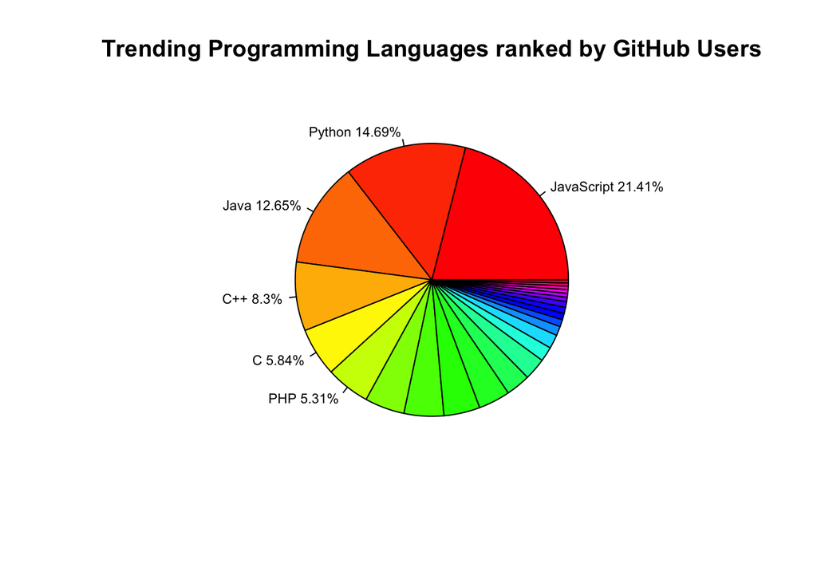

### I will give Cleveland this.

One of Cleveland’s arguments in his book is that the stacked bar chart isn’t easy for the human eye to understand at a glance. This makes sense. Since each bar isn’t linearly lined up and easily comparable, it’s hard for the human eye to judge minute differences in area. While a stacked bar plot is illogically laid out, a pie chart is visually appealing and informative.

## Conclusion

Contrary to R documentation and some statisticians, I believe that there are certainly contexts where pie charts are appropriate. Lots of scenarios that involves percentages warrant a well-labeled pie charts.